# Лабораторная работа №5

## Гипоциклоида

Гипоциклоида — плоская кривая, образуемая точкой окружности, катящейся по внутренней стороне другой окружности без скольжения.

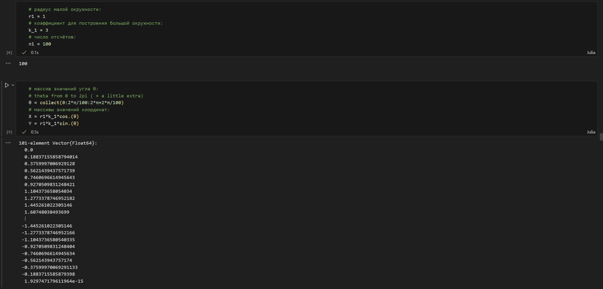

Построение большой окружности гипоциклоиды

## Гипоциклоида

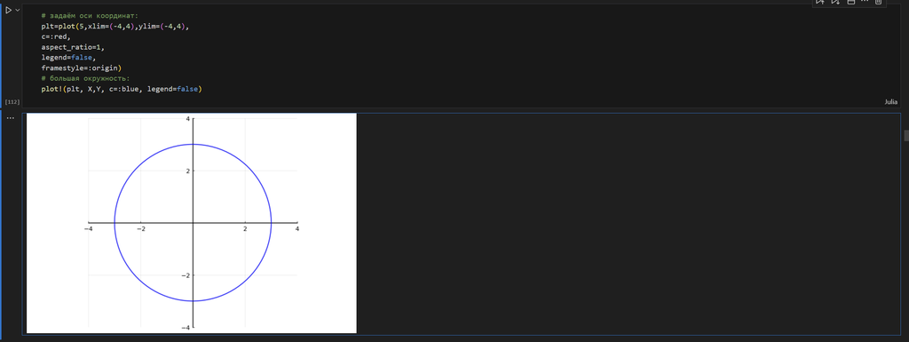

Большая окружность гипоциклоиды

## Гипоциклоида

Для частичного построения гипоциклоиды будем менять параметр t:

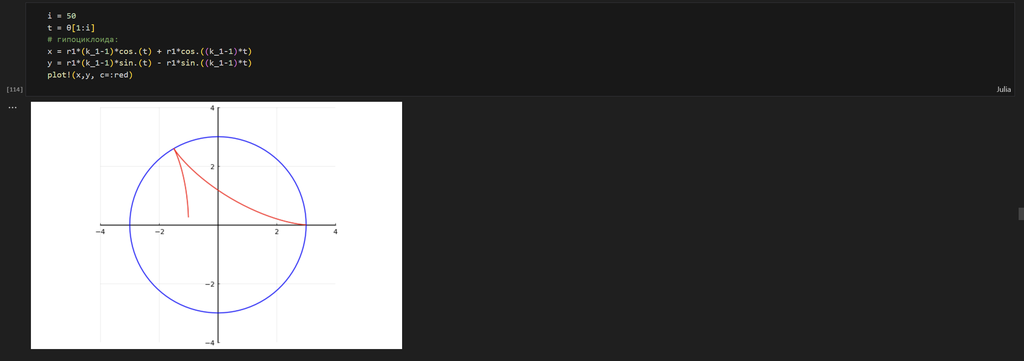

Половина пути гипоциклоиды

## Гипоциклоида

Добавляем малую окружность гипоциклоиды:

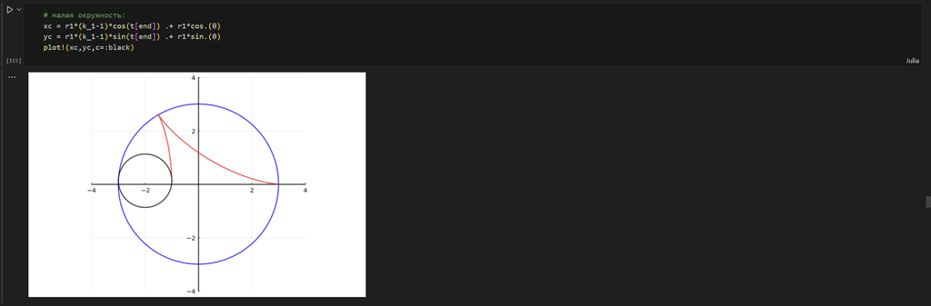

Малая окружность гипоциклоиды

## Гипоциклоида

Добавим радиус для малой окружности:

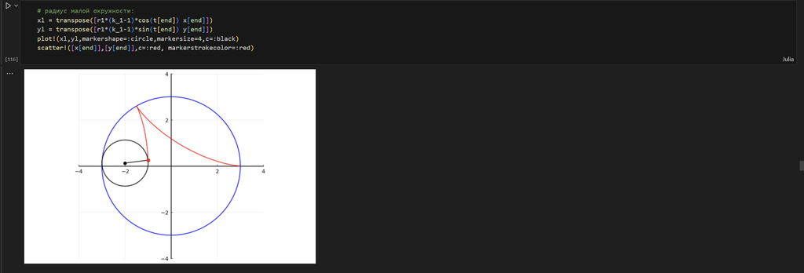

Малая окружность гипоциклоиды с добавлением радиуса

## Errorbars

В исследованиях часто требуется изобразить графики погрешностей измерения.

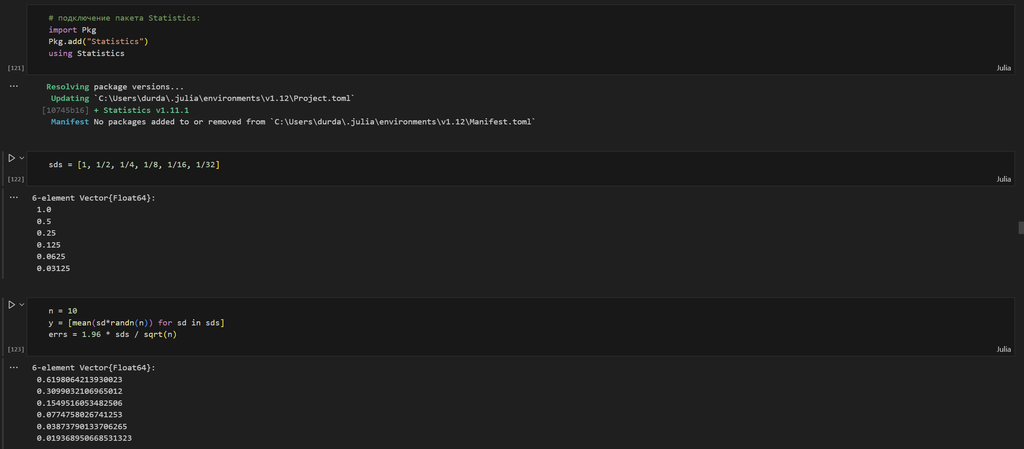

Зададим исходные значения

## Errorbars

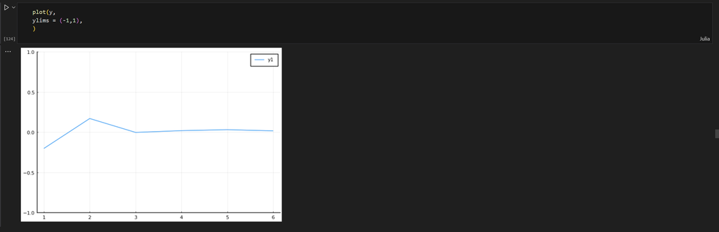

График исходных значений

## Errorbars

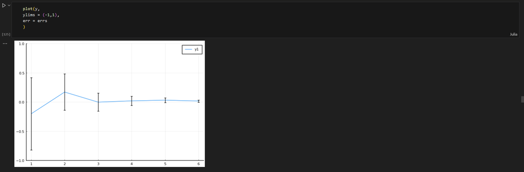

График исходных значений с отклонениями

## Errorbars

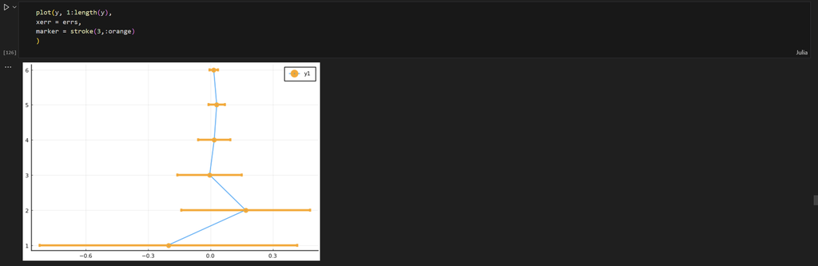

Поворот графика

## Errorbars

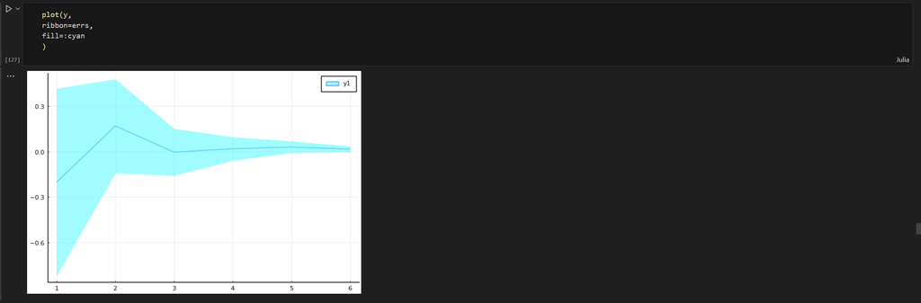

Заполнение цветом

## Errorbars

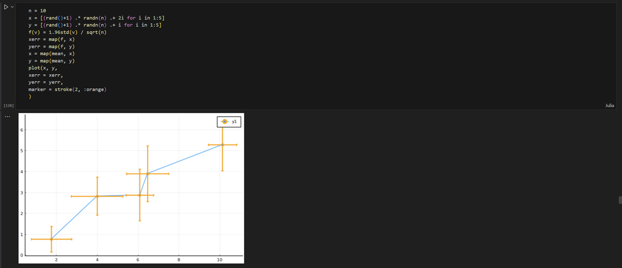

График ошибок по двум осям

## Errorbars

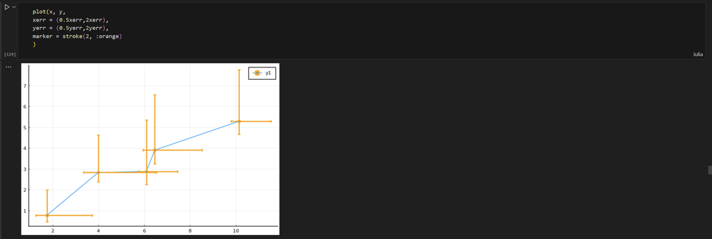

График асимметричных ошибок по двум осям

## Использование пакета Distributions

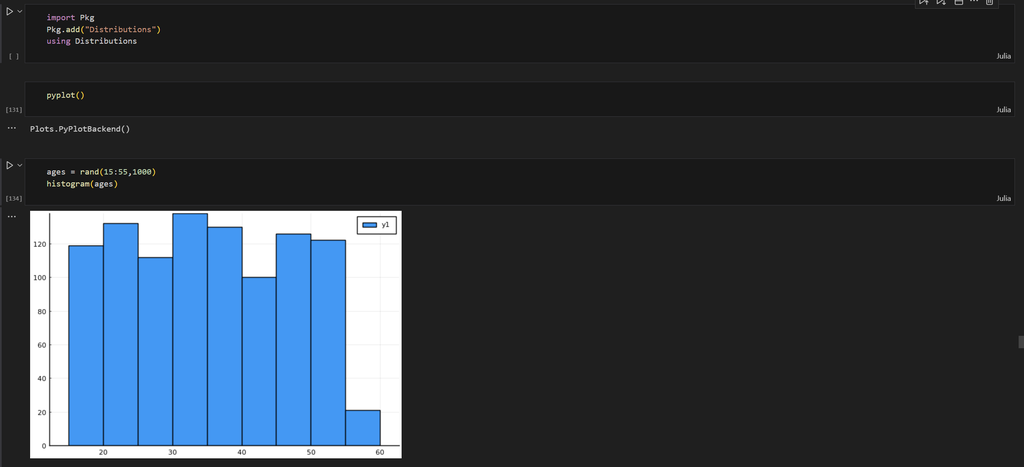

Гистограмма, построенная по массиву случайных чисел

## Использование пакета Distributions

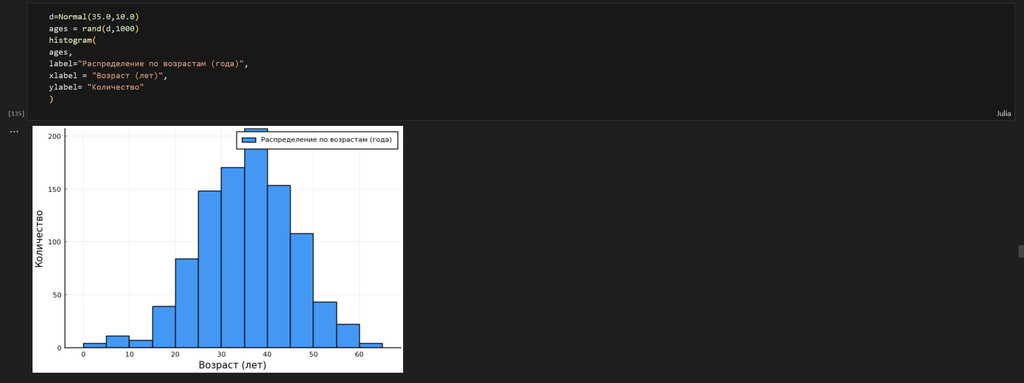

Гистограмма нормального распределения

## Подграфики

Определим макет расположения графиков. Команда layout принимает кортеж layout = (N, M), который строит сетку графиков NxM. Например, если задать layout = (4,1) на графике четыре серии, то получим четыре ряда графиков:

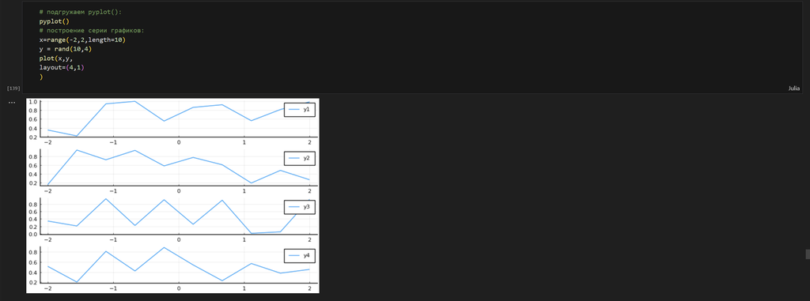

Серия из 4-х графиков в ряд

## Подграфики

Для автоматического вычисления сетки необходимо передать layout целое число:

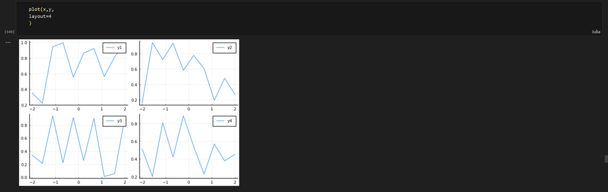

Серия из 4-х графиков в сетке

## Подграфики

Аргумент heights принимает в качестве входных данных массив с долями желаемых высот. Если в сумме дроби не составляют 1,0, то некоторые подзаголовки могут отображаться неправильно.

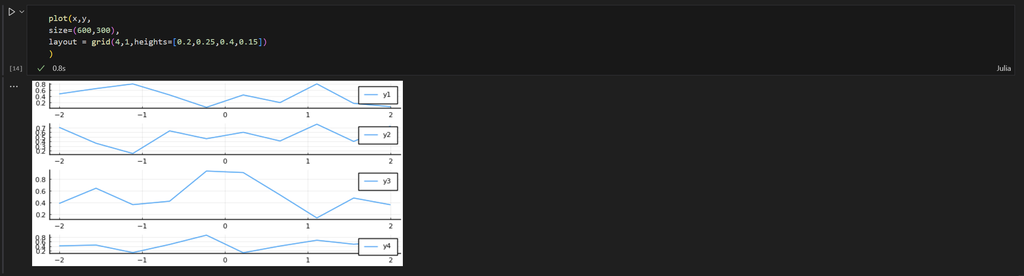

Серия из 4-х графиков разной высоты в ряд

## Подграфики

Можно сгенерировать отдельные графики и объединить их в один, например, в сетке 2 × 2:

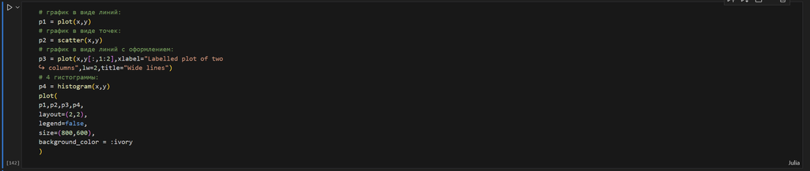

Объединение нескольких графиков в одной сетке

## Подграфики

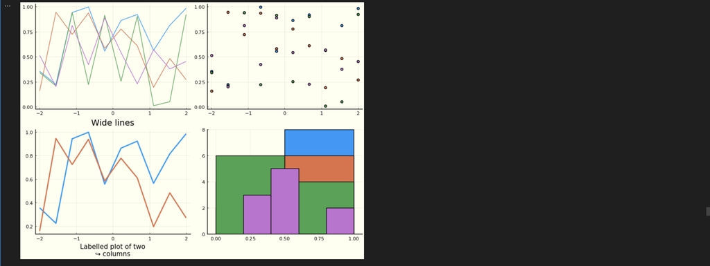

Объединение нескольких графиков в одной сетке

## Подграфики

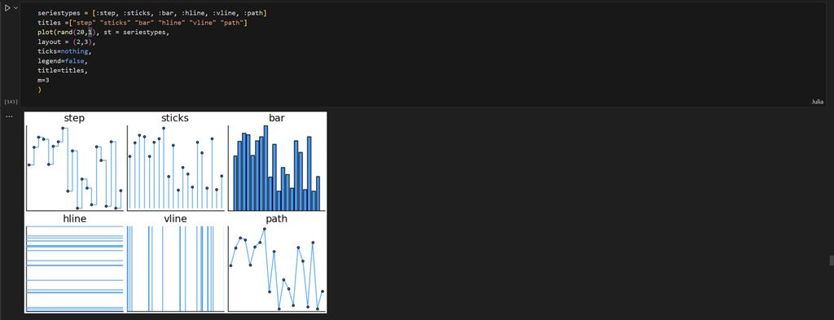

Разнообразные варианты представления данных

## Подграфики

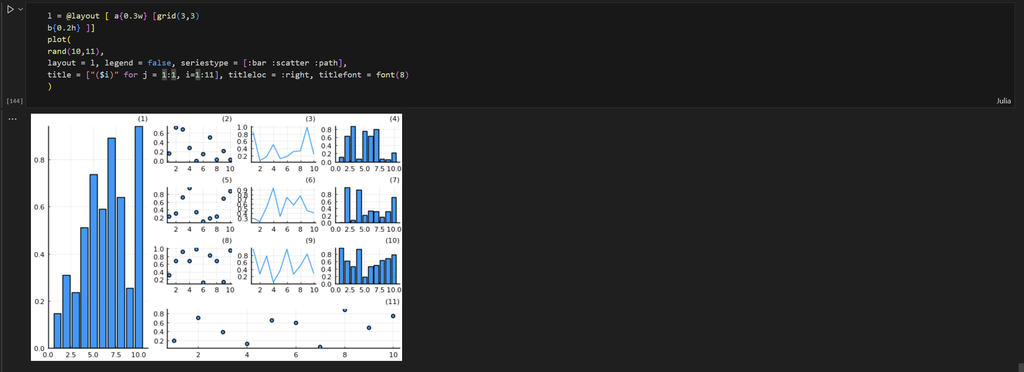

Демонстрация применения сложного макета для построения графиков

## Самостоятельное выполнение

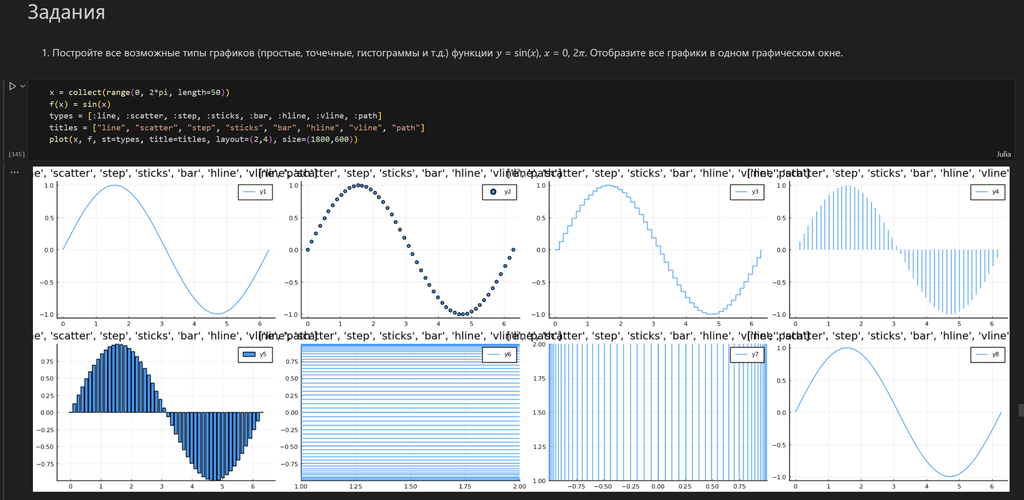

Решение задания №1

## Самостоятельное выполнение

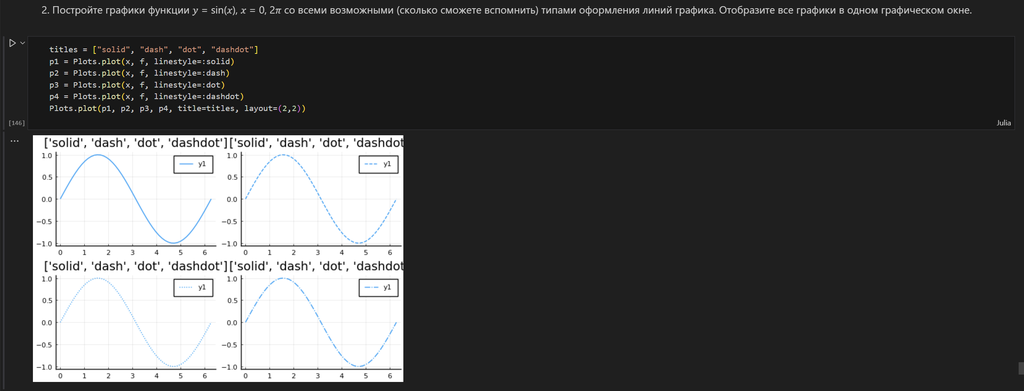

Решение задания №2

## Самостоятельное выполнение

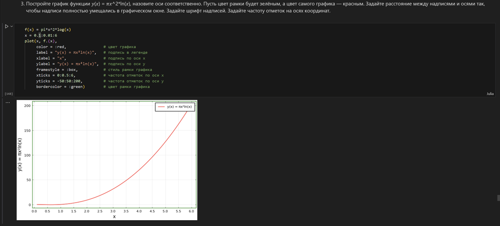

Решение задания №3

## Самостоятельное выполнение

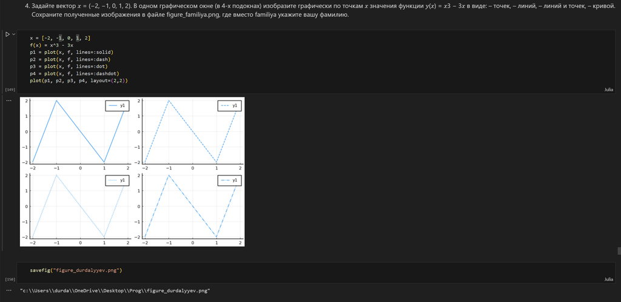

Решение задания №4

## Самостоятельное выполнение

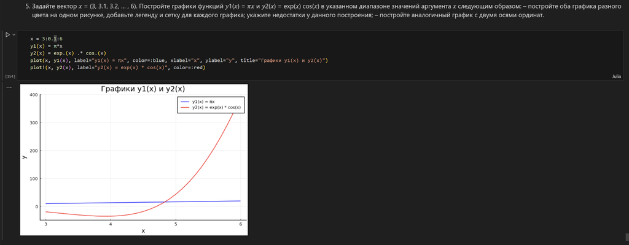

Решение задания №5

## Самостоятельное выполнение

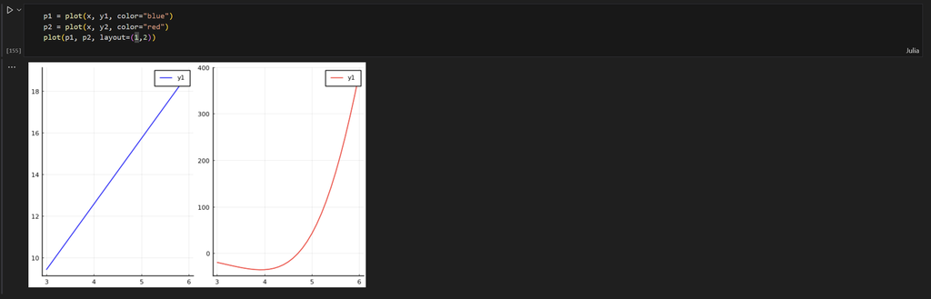

Решение задания №5

## Самостоятельное выполнение

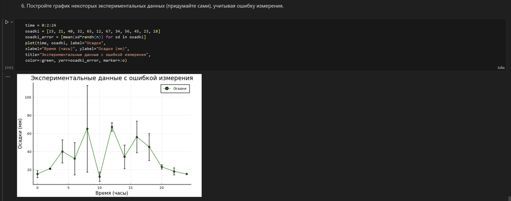

Решение задания №6

## Самостоятельное выполнение

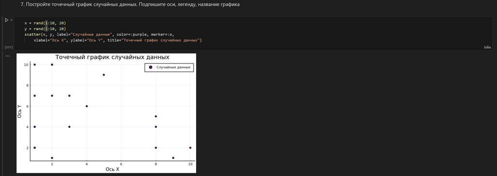

Решение задания №7

## Самостоятельное выполнение

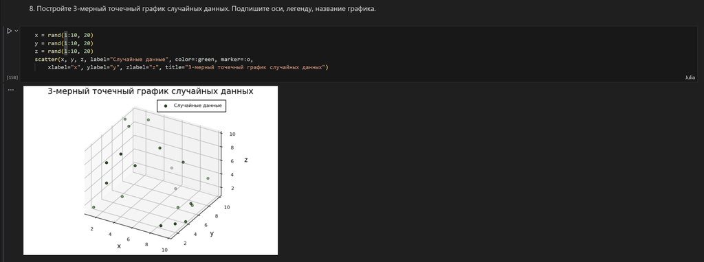

Решение задания №8

## Самостоятельное выполнение

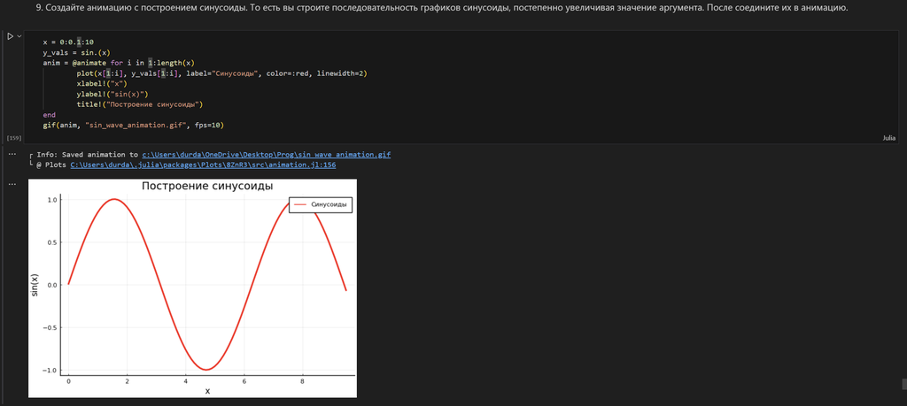

Решение задания №9

## Самостоятельное выполнение

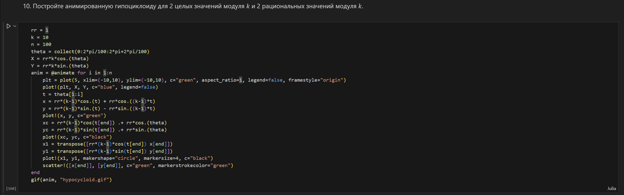

Решение задания №10

## Самостоятельное выполнение

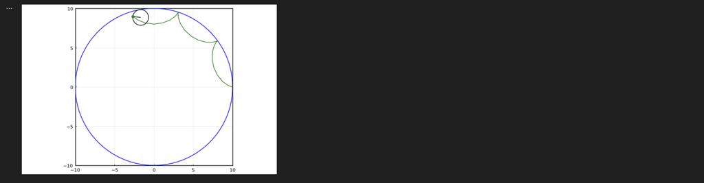

Решение задания №10

## Самостоятельное выполнение

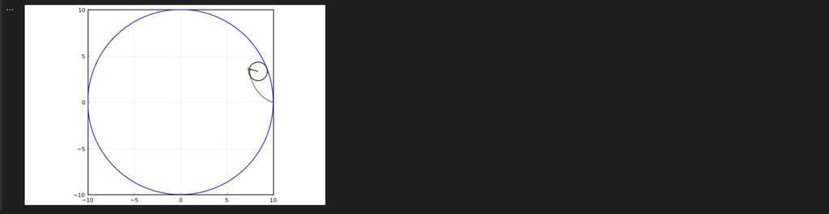

Решение задания №10

## Самостоятельное выполнение

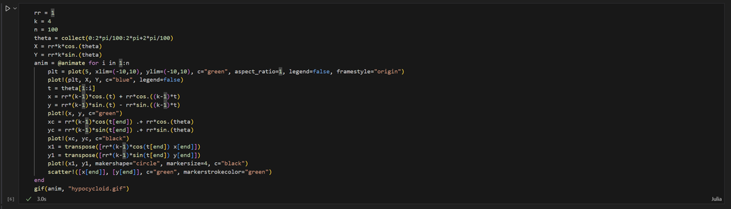

Решение задания №10

## Самостоятельное выполнение

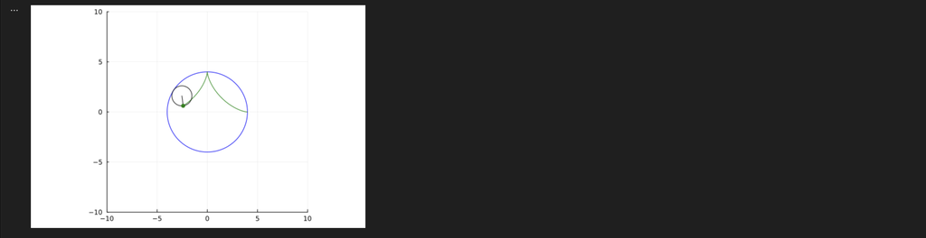

Решение задания №10

## Самостоятельное выполнение

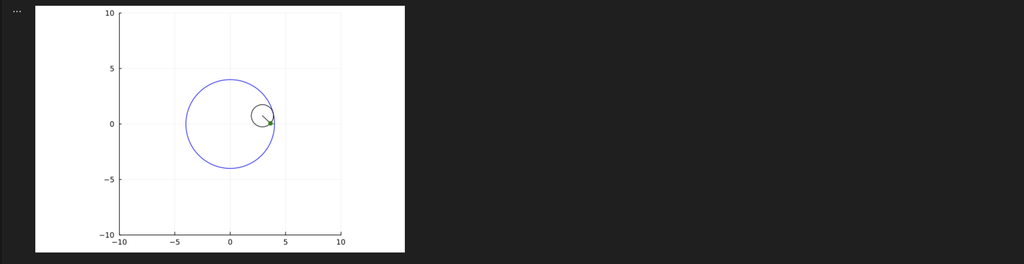

Решение задания №10

## Самостоятельное выполнение

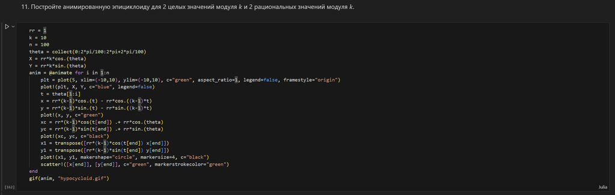

Решение задания №11

## Самостоятельное выполнение

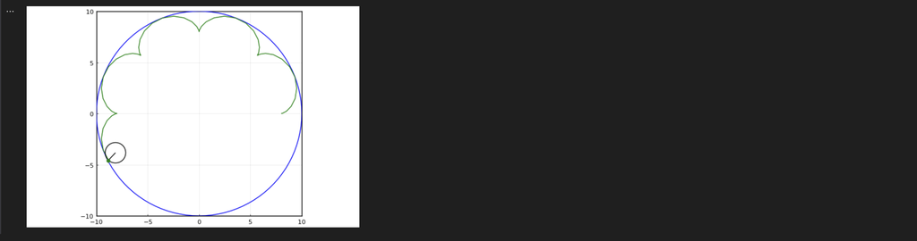

Решение задания №11

## Самостоятельное выполнение

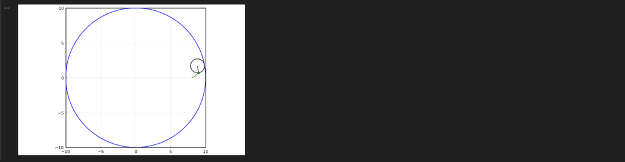

Решение задания №11

## Самостоятельное выполнение

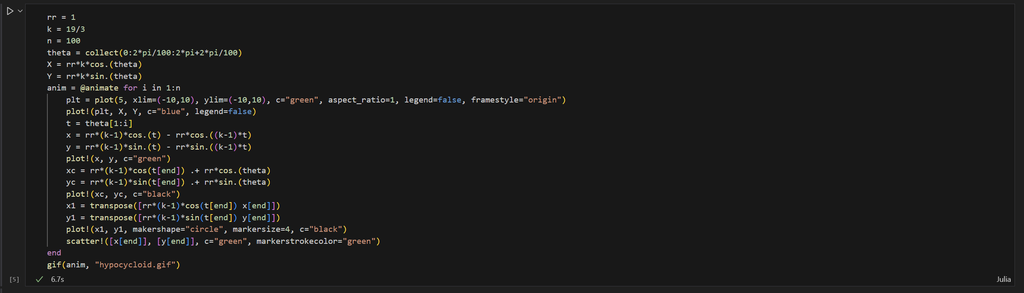

Решение задания №11

## Самостоятельное выполнение

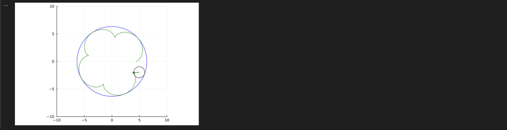

Решение задания №11

## Самостоятельное выполнение

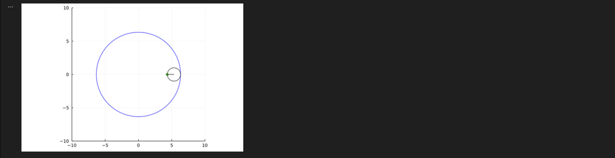

Решение задания №11

## Выводы

В результате выполнения данной лабораторной работы я освоил синтаксис языка Julia для построения графиков.